# FINAL EXAMINATION

- Các bạn có thời gian làm bài là 2.5h (Từ 15h40 - 18h00)
- Chỉ được sử dụng tài liệu có sẵn và không được sử dụng những tài liệu tham khảo là AI(ChatGPT, Gemini,...)
- Cố gắng làm hết khả năng của mình nha :)

# Câu 1: 2 Điểm

```python
from sklearn.datasets import load_iris
from sklearn.model_selection import train_test_split
from sklearn.naive_bayes import GaussianNB
from sklearn.metrics import accuracy_score, classification_report
# 1. Tải dữ liệu Iris
iris = load_iris()
X = iris.data
# 2. Chia dữ liệu thành tập huấn luyện và kiểm tra
X_train, X_test, y_train, y_test = train_test_split(X, y, test_size=0.9, random_state=42)
# 3. Tạo mô hình Naive Bayes
model = GaussianNB()
# 4. Huấn luyện mô hình
model.fit(x, X_test)
# 5. Dự đoán trên tập kiểm tra
y_prediction = model.predict(X_test)

# 6. Đánh giá mô hình
accuracy = accuracy(y_test, y_prediction)
print("Độ chính xác của mô hình:", accuracy)
# 7. Dự đoán với một mẫu mới
new_sample = [5.1, 3.5, 1.4, 0.2]
predicted_class = model.predict(new_sample)
print(f"Mẫu mới được dự đoán là lớp: {iris.target_names[y_prediction]}")
```

```
---------------------------------------------------------------------------
NameError                                 Traceback (most recent call last)
Cell In[52], line 13
     11 model = GaussianNB()
     12 # 4. Huấn luyện mô hình
---> 13 model.fit(x, X_test)
     14 # 5. Dự đoán trên tập kiểm tra
     15 y_prediction = model.predict(X_test)

NameError: name 'x' is not defined
```

### Đoạn code trên đúng hay sai hay bất thường? Nếu sai hoặc bất thường thì sửa lại như thế nào cho đúng ?

```python
from sklearn.datasets import load_iris
from sklearn.model_selection import train_test_split
from sklearn.naive_bayes import GaussianNB
from sklearn.metrics import accuracy_score, classification_report
import numpy as np
# 1. Tải dữ liệu Iris
iris = load_iris()
X = iris.data
y = iris.target
# 2. Chia dữ liệu thành tập huấn luyện và kiểm tra
X_train, X_test, y_train,y_test = train_test_split(X, y, test_size=0.3, random_state=42)
# 3. Tạo mô hình Naive Bayes
model = GaussianNB()
# 4. Huấn luyện mô hình
model.fit(X_train, y_train)
# # 5. Dự đoán trên tập kiểm tra
y_prediction = model.predict(X_test)

# # 6. Đánh giá mô hình
accuracy = accuracy_score(y_test, y_prediction)
print("Độ chính xác của mô hình:", accuracy)
# 7. Dự đoán với một mẫu mới
new_sample = np.array([[5.1, 3.5, 1.4, 0.2]])
predicted_class = model.predict(new_sample)
print(f"Mẫu mới được dự đoán là lớp: {iris.target_names[predicted_class]}")
```

```
Độ chính xác của mô hình: 0.9777777777777777
Mẫu mới được dự đoán là lớp: ['setosa']
```

```python
type(X_test)
```

```
numpy.ndarray
```

# Câu 2: 3 Điểm

Giả sử SVM tuyến tính tối ưu có $\mathbf{w} = \begin{bmatrix} 1 & 1 \end{bmatrix}^\top$ và $b = -2$. Tìm biên hình học $\gamma^{(i)}$ cho $\mathbf{x}^{(i)} = \begin{bmatrix} 2 & 5 \end{bmatrix}^\top$ và $y^{(i)} = 1$.

**Biên hình học cho ví dụ $i$ là $$\gamma^{(i)} = y^{(i)} \left( \frac{\mathbf{w}^\top \mathbf{x}^{(i)}}{\| \mathbf{w} \|} + \frac{b}{\| \mathbf{w} \|} \right),$$ theo code bên dưới là 3.536.**

```python
#code here
import numpy as np

def gamma(w: np.array, b, x: np.array, y):
  return y*(((w.T * x) + b)/np.sqrt(np.sum(w ** 2)) )[0][1] + np.sqrt(np.sum(w ** 2))
```

```python
gamma(np.array([[1, 1]]), -2, np.array([[2, 5]]), 1)
```

```
3.5355339059327378
```

Kết quả tham khảo:

Gamma = 3.536

# Câu 3: 5 Điểm

Điền vào chỗ trống bên dưới để mô hình MLP có thể hoạt động tốt và cho kết quả chính xác

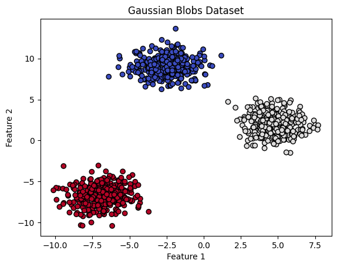

```python
import torch
import torch.nn as nn
import torch.optim as optim
import numpy as np
import matplotlib.pyplot as plt
from sklearn.datasets import make_blobs
from sklearn.model_selection import train_test_split
from sklearn.preprocessing import StandardScaler

# 1. Tạo dữ liệu Gaussian blobs
X, y = make_blobs(n_samples=1000, centers=3, cluster_std=1.2, random_state=42)

# Vẽ dữ liệu để kiểm tra
plt.scatter(X[:, 0], X[:, 1] , c=y, cmap=plt.cm.coolwarm, edgecolor='k')
plt.title("Gaussian Blobs Dataset")
plt.xlabel("Feature 1")
plt.ylabel("Feature 2")
plt.show()
```

Kết quả tham khảo :

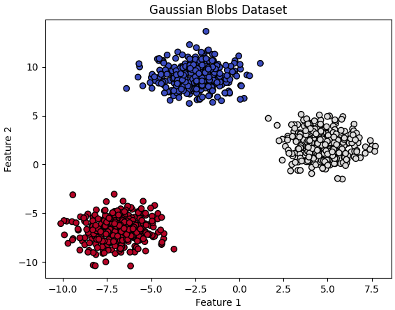

```python
# 2. Chia dữ liệu thành train/test
np.random.seed(42)
indices = np.random.permutation(X.shape[0]) #code here
np.random.shuffle(indices)
test_size = int(0.2*X.shape[0]) #code here # 20% cho tập test
train_size = int(0.8*X.shape[0]) #code here

train_indices = indices[:train_size] #code here
test_indices = indices[train_size:] #code here

X_train = X[train_indices] #code here
y_train = y[train_indices] #code here
X_test = X[test_indices] #code here
y_test = y[test_indices] #code here
```

```python
# Chuẩn hóa dữ liệu
# mean = np.mean(y) #code here  # Trung bình của mỗi đặc trưng
# std = np.std(y) #code here   # Độ lệch chuẩn của mỗi đặc trưng
# X_train =  #code here # Chuẩn hóa tập train
# # X_test = #code here   # Chuẩn hóa tập test theo mean và std của tập train

# # Chuyển đổi dữ liệu thành PyTorch tensors
X_train = torch.tensor(X_train) #code here)
y_train = torch.tensor(y_train) #code here
X_test = torch.tensor(X_test) #code here
y_test = torch.tensor(y_test) #code here
# mean
```

```python
# 3. Xây dựng mô hình MLP
class MLP(nn.Module):
    def __init__(self):
        super(MLP, self).__init__()
        self.fc1 = nn.Linear(2, 4)#code here  # 2 đặc trưng đầu vào -> 4 nơ-ron ẩn
        self.relu1 = nn.ReLU() #code here      # Hàm kích hoạt ReLU
        self.fc2 = nn.Linear(4, 2) #code here  # 4 nơ-ron ẩn -> 2 nơ-ron ẩn
        self.relu2 = nn.ReLU()    # Hàm kích hoạt ReLU
        self.fc3 = nn.Linear(2, 3) #code here  # 2 nơ-ron ẩn -> 3 lớp đầu ra

    def forward(self, x):
        x = self.fc1(x)
        x = self.relu1(x)
        x = self.fc2(x)
        x = self.relu2(x)
        x = self.fc3(x)
        return x
```

```python
# 4. Khởi tạo mô hình, hàm mất mát, và bộ tối ưu
model = MLP()
criterion = nn.CrossEntropyLoss()  # Hàm mất mát CrossEntropy cho bài toán phân loại
optimizer = torch.optim.SGD(params = model.parameters(), lr = 0.01) # Tối ưu hóa bằng SGD với lr= 0.01
```

```python
losses = []

# Huấn luyện mô hình
epochs = 10000
for epoch in range(epochs):
    model.train()
    outputs = model(X_train)
    loss = criterion(outputs, y_train)

    # Lưu loss vào danh sách
    losses.append(loss.item())
    #code here

    #code here
    #code here
    #code here
    loss.backward()
    optimizer.step()

    if (epoch + 1) % 100 == 0:
        print(f"Epoch [{epoch+1}/{epochs}], Loss: {loss.item():.4f}")

# 6. Đánh giá mô hình
model.eval()
with torch.no_grad():
    outputs = model(X_test)
    _, predicted = torch.max(outputs, 1)  # Lấy nhãn dự đoán
    accuracy = (predicted == y_test).float().mean()  # Tính độ chính xác
    print(f"Accuracy on test set: {accuracy.item():.4f}")

# Vẽ biểu đồ loss
#code here
```

[output not shown]

Kết quả tham khảo

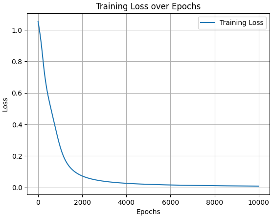

```python
# 7. Vẽ quyết định ranh giới
def plot_decision_boundary(model, X, y):
    x_min, x_max = X[:, 0].min() - 1, X[:, 0].max() + 1
    y_min, y_max = X[:, 1].min() - 1, X[:, 1].max() + 1
    xx, yy = np.meshgrid(np.arange(x_min, x_max, 0.01),
                         np.arange(y_min, y_max, 0.01))
    grid = np.c_[xx.ravel(), yy.ravel()]
    grid_tensor = torch.tensor(grid, dtype=torch.float32)

    with torch.no_grad():
        preds = model(grid_tensor)
        preds = torch.argmax(preds, axis=1).numpy()

    plt.contourf(xx, yy, preds.reshape(xx.shape), alpha=0.8, cmap=plt.cm.coolwarm)
    plt.scatter(X[:, 0], X[:, 1], c=y, cmap=plt.cm.coolwarm, edgecolors='k')
    plt.title("Decision Boundary")
    plt.xlabel("Feature 1")
    plt.ylabel("Feature 2")
    plt.show()

#Ranh giới phân loại
plot_decision_boundary(model, np.vstack((X_train.numpy(), X_test.numpy())), np.hstack((y_train.numpy(), y_test.numpy())))
```

Kết quả Tham khảo:

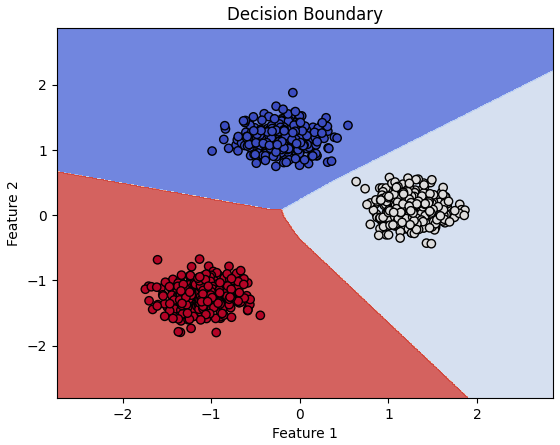